# Understanding Matrices and Logistic Regression in Neural Networks

In this document, we explore the foundations of matrices in neural networks, logistic regression, forward propagation, and updating weights using stochastic gradient descent. We will implement a basic example in `R` to reinforce learning.

# 1 Understanding Matrices in Neural Networks

Matrices enable efficient mathematical operations in neural networks. For a simple model:

$$Z = XW$$

where:

- $X$ is the **input matrix** (containing feature values).
- $W$ is the **weight matrix** (containing learned coefficients).
- $Z$ is the **output before activation**.

### 1.0.1 **Traditional Logistic Regression Notation**

In standard **logistic regression**, the equation is expressed using individual predictor variables:

$$Z = \beta_0 + \beta_1 x_1 + \beta_2 x_2 + \dots + \beta_n x_n$$

where:

- $\beta_0$ is the **intercept (bias term)**.
- $\beta_1, \beta_2, \dots, \beta_n$ are the **weights (coefficients) assigned to each feature**.
- $x_1, x_2, \dots, x_n$ are the **input feature values** (e.g., time spent, pages visited).
- $Z$ is the **linear combination before applying the activation function**.

Once $Z$ is computed, the logistic function (**sigmoid activation**) is applied:

$$\sigma(Z) = \frac{1}{1 + e^{-Z}}$$
{eq-sigmoid-function}

Both forms describe the same underlying concept:

- The **matrix form** ($Z = XW$) is compact and efficient, especially when handling multiple samples.
- The **traditional logistic regression form** explicitly shows the relationship between individual features and their respective weights.

Both representations lead to the same outcome: a **probability prediction** via the sigmoid function.

The term $Z$ in the sigmoid activation function is most commonly referred as the weighted sum of imputs (plus bias)

Herer’s a breakdown: In a single neuron, before an activation function is applied, a neuron takes multiple inputs, multiplies each input by a corresponding weight, sums these weighted inputs, and then adds the bias term. So $Z$ represents the linear combination of the inputs to a neuron before any any non-linear transformation is applied.

**The concept around activation functions** 1. Introducing Non-linearity: this is the most important reason for activation functions. Imagine a neural network without activation functions. Each neuron would simply perform a linear transformation (weighted sum +bias). If you stack multiple layers of linear transformations, the entire network would still be a single linear transformation. Real world data is almost never linearly separable. Problems like image recognition, natural language or complex pattern detection involve highly non-linear relationships. Activation functions introduce non-linearity, allowing neural network to learn and approximate complex, non-linear functions and relationships in the data. You can think of an activation function as determining whether a neuron should “activate” or “fire” and pass its signal to the next layer. It transforms the raw, unbounded weighted sum (Z) into an output that is typically within a specific range, often interpreted as probability or a strength of activation. Sigmoid maps any real number (Z) to a value between 0 and 1. This makes it ideal for output layers in binary classification problems, where the output can be interpreted as a probability.

# 2 Logistic Regression Model

Logistic regression predicts probabilities using the **sigmoid function**: The sigmoid function is a mathematical function that outputs values between 0 and 1, making it ideal for logistic regression, where we interpret the result as a probability.

$$\sigma(Z) = \frac{1}{1 + e^{-Z}}
\tag{1}$$

- $Z$ is the input value (can be any real number)
- $e$ is Euler’s number

**Tip**

If $Z$ is large and positive,$\sigma(z)$ approaches 1 (strong positive probability)

If $z$ is large and negative,$\sigma(z)$ approaches 0 (strong negative probability)

when $z=0$, $\sigma(z)=0.5)$, meaning neutral probability

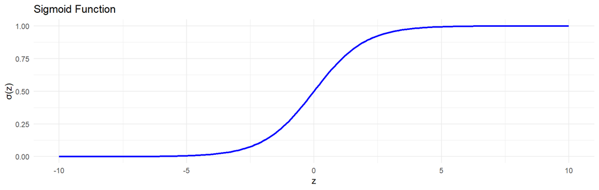

# 3 Forward Propagation & Loss Function

Predictions ($\hat{y}$) are made using:
$$\hat{y} = \sigma(Z)$$
The **binary cross-entropy loss function** quantifies the error between the estimate and the real output provided to the model:
$$L = -\frac{1}{m} \sum_{i=1}^{m} \left[ y_i \log(\hat{y}_i) + (1 - y_i) \log(1 - \hat{y}_i) \right]
\tag{2}$$

# 4 Updating Weights with Gradient Descent

Since we don’t know the optimal values of $W$, we start with random weights and iteratively update them to minimize the loss function. Now, let’s break down the equation further and clarify the partial derivatives.

Gradient loss function:
$$dw =\frac{\partial L}{\partial W} = \frac{1}{m} X^T (A-Y)
\tag{3}$$

This term represents the gradient, or the slope, of the loss function $L$ with respect to $W$. Essentially, it tells us:

How much the loss function changes when we slightly change$W$ The direction we should move $W$ to minimize the loss.

Since $L$ depends on $W$ (because changing 𝑊affects predictions), we need to calculate the rate of change of $L$ concerning $W$, which is where the partial derivative comes in.

*Partial Derivatives Explained* A partial derivative calculates how one variable changes while keeping others constant. In our case:
$$\frac{\partial L}{\partial W}$$
measures how much the loss function changes if we make a small adjustment to $W$. If we visualize the loss function as a mountain, the gradient tells us which direction leads us downhill the fastest (toward lower loss). The gradient gives the best direction for adjusting W, but how far we step in that direction is controlled by the learning rate $\alpha$

$$W = W -\alpha \cdot \frac{\partial L}{\partial W}$$
Where:

- $\alpha$ is the **learning rate** (a small step size to prevent large jumps)
- $\frac{\partial L}{\partial W}$ is the **gradient**

$W$ is updated gradually with each iteration.

For logistic regression, the gradient of the *binary cross-entropy loss function* with respect to $W$ is:
$$\frac{\partial L}{\partial W} = \frac{1}{m}X^T(\hat y -y)$$
Where:

- $X$ is the input matrix (features)
- $y$ is the actual target values.
- $\hat y = \sigma(XW)$ is the predicted output after applying the sigmoid function.
- $X^T(\hat y- y)$ measures the error’s contribution to weight updates.

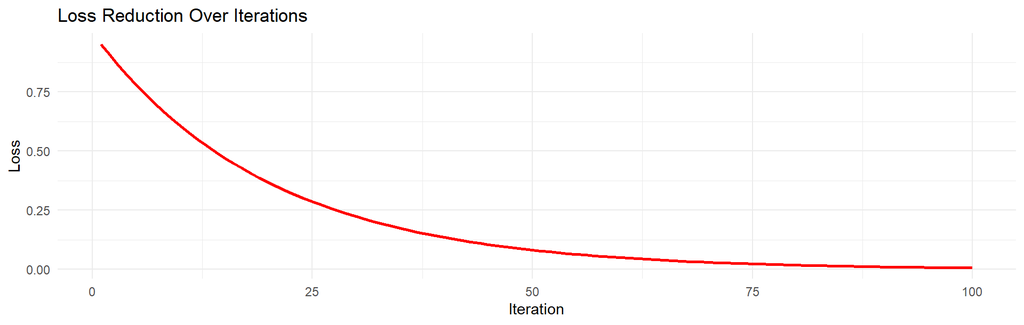

```r
# Example loss reduction over iterations
iterations <- seq(1, 100)
loss_values <- exp(-0.05 * iterations)  # Simulated loss decreasing

# Create dataframe
df <- data.frame(iteration = iterations, loss = loss_values)

# Plot loss reduction
ggplot(df, aes(x = iteration, y = loss)) +
  geom_line(color = "red", size = 1) +
  ggtitle("Loss Reduction Over Iterations") +
  xlab("Iteration") +
  ylab("Loss") +
  theme_minimal()
```

# 5 Implementation in R

Scenario: Predicting Whether Someone Will Buy a Product Imagine you’re running an online store, and you want to predict whether a customer will buy a product based on two simple features:

- Time spent on the website (in minutes)
- Number of pages visited

We’ll create a small dataset with these features and train a logistic regression model using gradient descent to predict whether a customer will buy the product (1) or not (0).

The traditional logistical regression formula would be:
$$Z=\beta_0+\beta_1 x_{1i}+\beta_2 x_{2i}+\epsilon_i$$

where:

- $\beta_0$ is the **intercept (bias term)**.
- $\beta_1, \beta_2$ are the **weights (coefficients) assigned to each feature**.
- $x_{1i}, x_{2i}$ are the **feature values** for the$i$-th sample.
- $\epsilon_i$ is the **error term** accounting for noise in the data.

Instead of writing the equation explicitly for each feature, we can use matrix multiplication:

$$Z = XW + \epsilon$$

Where:

- $X$ is the **input matrix** containing feature values.
- $W$ is the **weight matrix** (vector of coefficients).
- $\epsilon$ is the **error term**.

Expanding this in **matrix notation**:

$$\begin{bmatrix}
Z_1 \\
Z_2 \\
Z_3 \\
\vdots \\
Z_m
\end{bmatrix}=\begin{bmatrix}
1 & x_{11} & x_{21} \\
1 & x_{12} & x_{22} \\
1 & x_{13} & x_{23} \\
\vdots & \vdots & \vdots \\
1 & x_{1m} & x_{2m}
\end{bmatrix} \begin{bmatrix}
\beta_0 \\
\beta_1 \\
\beta_2
\end{bmatrix}+ \begin{bmatrix}
\epsilon_1 \\
\epsilon_2 \\
\epsilon_3 \\
\vdots \\ \epsilon_m
\end{bmatrix}$$

Where:

- Each row in $X$ represents **one sample**, including a **bias term (1), feature 1, and feature 2**.
- The column vector $W$ contains the **learned parameters** ($\beta_0, \beta_1, \beta_2$).
- The error term $\epsilon$ accounts for **random noise in predictions**.

We have data from 5 customers, we will create a matrix for this: Each row in $X$ represents a customer. First column = Bias term (always 1). Second column = Time spent on the website. Third column = Number of pages visited. y contains whether the customer bought the product (1) or not (0).

```r
 # Real-world dataset (Time spent & Pages visited)
X <- matrix(c(
  1, 5, 2,
  1, 15, 5,
  1, 20, 7,
  1, 2, 1,
  1, 30, 10
), ncol=3, byrow=TRUE)

y <- c(0, 1, 1, 0, 1)  # Labels
```

As a recapitulation, we use the *sigmoid* function to predict the expected output of any specific combination of minutes in the website and pages visited. We will create a function for this:

```r
# Sigmoid function
sigmoid <- function(z) {
  return(1 / (1 + exp(-z)))
}
```

The *loss function* will tell us how far our predicted value is from the actual value, we will also create a function for this:

```r
# Loss function (binary cross-entropy)
loss_function <- function(y, y_hat) {
  return(-mean(y * log(y_hat) + (1 - y) * log(1 - y_hat)))
}
```

Now we create a function to calculate the *gradient descent*

```r
gradient_descent <- function(X, y, learning_rate = 0.01, iterations = 50) {
  m <- nrow(X)
  W <- runif(ncol(X))  # Initialize weights randomly
  for (i in 1:iterations) {
    Z <- X %*% W   # Compute Z values for all samples
    y_hat <- sigmoid(Z)  # Apply sigmoid function to all samples
    gradient <- t(X) %*% (y_hat - y) / m  # Compute gradient for weight updates
    W <- W - learning_rate * gradient  # Update weights
  }
  return (W)
}
```

Just for learning purposes, we will create a new version of the gradient descent function where we store the results of each iteration, so we can visualize it later:

```r
# Gradient Descent Implementation (Tracking Progress)
gradient_descent_progress <- function(X, y, learning_rate = 0.01, iterations = 50) {
  m <- nrow(X)
  W <- runif(ncol(X))  # Initialize weights randomly
  progress <- data.frame(Iteration = integer(),
                         Weight1 = numeric(), Weight2 = numeric(),
                         Z1 = numeric(), Z2 = numeric(), Z3 = numeric(), Z4 = numeric(), Z5 = numeric(),
                         y_hat1 = numeric(), y_hat2 = numeric(), y_hat3 = numeric(), y_hat4 = numeric(), y_hat5 = numeric(),
                         Grad1 = numeric(), Grad2 = numeric())  # Tracking all five samples

  for (i in 1:iterations) {
    Z <- X %*% W   # Compute Z values for all samples
    y_hat <- sigmoid(Z)  # Apply sigmoid function to all samples
    gradient <- t(X) %*% (y_hat - y) / m  # Compute gradient for weight updates
    W <- W - learning_rate * gradient  # Update weights

    # Store results for all five samples
    progress <- rbind(progress, data.frame(
      Iteration = i,
      Weight1 = W[2], Weight2 = W[3],
      Z1 = Z[1], Z2 = Z[2], Z3 = Z[3], Z4 = Z[4], Z5 = Z[5],
      y_hat1 = y_hat[1], y_hat2 = y_hat[2], y_hat3 = y_hat[3], y_hat4 = y_hat[4], y_hat5 = y_hat[5],
      Grad1 = gradient[2], Grad2 = gradient[3]
    ))
  }

  return(progress)
}
```

At the beginning, the weights are random.

Over each iteration, the values change towards better predictions.

- $Z$ values show the raw linear transformation before activation.
- $\hat{y}$ (y_hat) tracks how probabilities evolve as weights adjust.
- Gradient values indicate how weights update to minimize the loss.

If you increase iterations, you’ll see further refinement.

```r
# Train Model
set.seed(2)
progress_df <- gradient_descent_progress(X, y)

print(head(progress_df))
```

```
  Iteration   Weight1   Weight2       Z1       Z2       Z3       Z4       Z5
1         1 0.6888648 0.5675639 4.843405 13.58712 18.24565 2.162957 26.98937
2         2 0.6753759 0.5618110 4.760556 13.35190 17.93135 2.126398 26.52269
3         3 0.6619085 0.5560680 4.677836 13.11703 17.61753 2.089897 26.05672
4         4 0.6484633 0.5503354 4.595251 12.88254 17.30422 2.053458 25.59151
5         5 0.6350416 0.5446137 4.512808 12.64845 16.99143 2.017082 25.12707
6         6 0.6216444 0.5389033 4.430512 12.41477 16.67920 1.980774 24.66346
     y_hat1    y_hat2    y_hat3    y_hat4 y_hat5    Grad1     Grad2
1 0.9921814 0.9999987 1.0000000 0.8968733      1 1.350927 0.5762460
2 0.9915118 0.9999984 1.0000000 0.8934425      1 1.348884 0.5752916
3 0.9907866 0.9999980 1.0000000 0.8899173      1 1.346747 0.5742961
4 0.9900013 0.9999975 1.0000000 0.8862965      1 1.344512 0.5732572
5 0.9891514 0.9999968 1.0000000 0.8825790      1 1.342173 0.5721731
6 0.9882318 0.9999959 0.9999999 0.8787636      1 1.339725 0.5710413
```

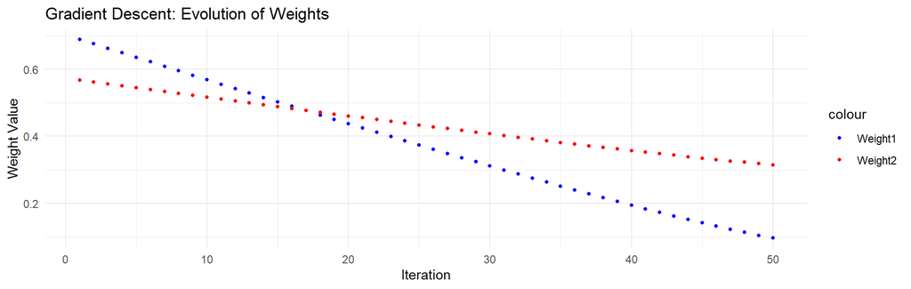

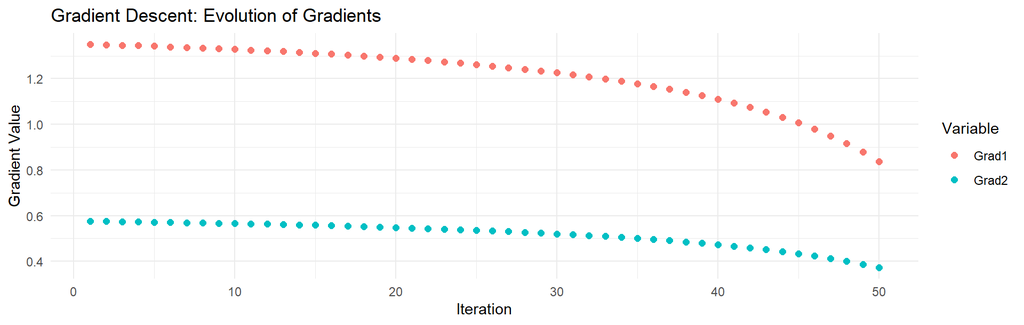

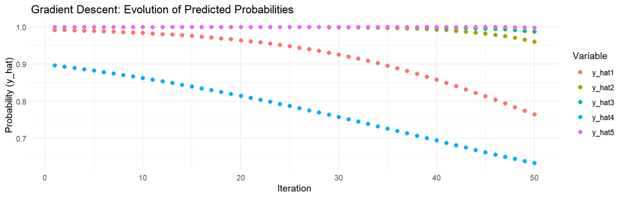

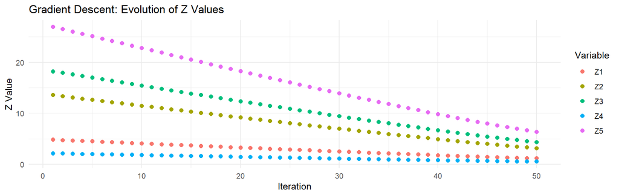

**Understanding the Learned Weights**

After running gradient descent, we obtained the following learned weights:

```r
set.seed(2)
# Gradient Descent Implementation (Track Progress)
gradient_descent <- function(X, y, learning_rate = 0.01, iterations = 50) {
  m <- nrow(X)
  W <- runif(ncol(X))  # Initialize weights randomly
  for (i in 1:iterations) {
    Z <- X %*% W   # Compute Z values for all samples
    y_hat <- sigmoid(Z)  # Apply sigmoid function to all samples
    gradient <- t(X) %*% (y_hat - y) / m  # Compute gradient for weight updates
    W <- W - learning_rate * gradient  # Update weights
  }
  return (W)
}
W <- gradient_descent(X, y)
print(W)
```

```
           [,1]
[1,] 0.01567795
[2,] 0.09666904
[3,] 0.31485151
```

These correspond to:

- $W_0$ **Bias term** (Intercept).
- $W_1$ **Effect of Time Spent on probability of purchasing**.
- $W_2$ **Effect of Pages Visited on probability of purchasing**.A positive value increases probability, while a negative value decreases probability.

To predict whether a new customer will buy a product, we use the following equation:

$$Z = W_0 + W_1 \cdot \text{Time Spent} + W_2 \cdot \text{Pages Visited}$$

Once we calculate$Z$, we apply the **sigmoid activation function**:

$$\sigma(Z) = \frac{1}{1 + e^{-Z}}$$

where $\sigma(Z)$ represents the **probability** that the customer will buy.

**Example Calculation** Let’s take a new customer who spends **12 minutes** on the website and visits **4 pages**. We calculate $Z$ as:

$$Z = 0.01567795 + (0.09666904 \times 12) + (0.31485151 \times 4)$$

Applying the *learned weights*, the prediction follows:

$$Z = 2.435112$$

Applying the *sigmoid* function:

$$\sigma(2.435112) = \frac{1}{1 + e^{-2.435112}}$$

Approximating:

$$\sigma(2.435112) \approx 0.91$$

Thus, the model predicts **91% probability** that this customer **will buy** the product.

Let’s see the predictions calculated in `r` over the same data we used for training:

```r
# Function to predict probability based on learned weights
predict_probability <- function(X, W) {
  return(sigmoid(X %*% W))
}
```

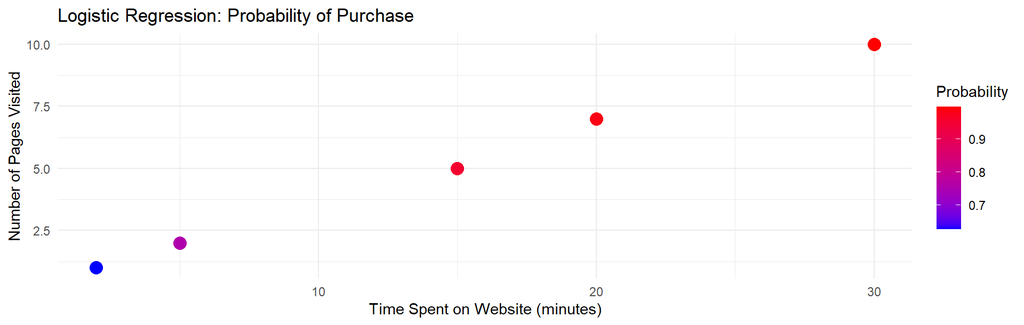

```r
# Get predictions
predicted_probs <- predict_probability(X, W)

# Create dataframe for plotting
df <- data.frame(TimeSpent = X[,2], PagesVisited = X[,3], Probability = predicted_probs)

# Plot results
ggplot(df, aes(x = TimeSpent, y = PagesVisited, color = Probability)) +
  geom_point(size = 4) +
  scale_color_gradient(low = "blue", high = "red") +
  ggtitle("Logistic Regression: Probability of Purchase") +
  xlab("Time Spent on Website (minutes)") +
  ylab("Number of Pages Visited") +
  theme_minimal()
```

We apply gradient descent to learn optimal weights and predict whether future customers will buy by minimizing the loss function iteratively.

# 6 Cat /Non-cat exercise

We are going to use the cat/non-cat dataset from `kaggle` package to see how to use these maths to find out if a given image is a cat or not a cat. The cat dataset comes in `hdf5`format so we will need to install a couple of libraries to load it.

Now we load the datasets for our model. You can download the data from cat/non-cat

**Data Loading and Preprocessing for Image Classification**

Before we can feed our “cat/non-cat” image data into our logistic regression model, we need to load it and transform it into a format that our matrix-based gradient descent implementation can efficiently process. Image data, especially raw pixel values, requires several crucial preprocessing steps to make it suitable for machine learning algorithms.

1. **Loading the HDF5 Dataset**

Our image dataset is stored in HDF5 (`.h5`) files, a format optimized for storing large arrays of numerical data. The dataset is conveniently split into two files: `train_catvsnoncat.h5` for training and `test_catvsnoncat.h5` for evaluation. Within each file, the image pixel data is typically stored under a key like `train_set_x` (or `test_set_x`), and their corresponding labels under `train_set_y` (or `test_set_y`).

We use the `h5read()` function from the `rhdf5` package to extract these specific datasets from the HDF5 files.

```r
library(rhdf5)
test_data_file_path <- file.path("data", "test_catvsnoncat.h5")
train_data_file_path <- file.path("data", "train_catvsnoncat.h5")

# Load training and test data
train_dataset <- h5read(train_data_file_path, "train_set_x")
train_labels <- h5read(train_data_file_path, "train_set_y")

# Load test data
test_dataset <- h5read(test_data_file_path, "test_set_x")
test_labels <- h5read(test_data_file_path, "test_set_y")
```

Raw image data is inherently multi-dimensional (e.g., `64 pixels height x 64 pixels width x 3 color channels for RGB`).

By looking at the dimensions of the datasets we can see that we have 209 images in the train dataset and 50 in the test dataset:

```r
dim(test_dataset)
```

```
[1]  3 64 64 50
```

```r
dim(train_dataset)
```

```
[1]   3  64  64 209
```

If we want to extract the data for the first cat image (the first cat image is the third image in the train dataset), for example:

```r
# Extract the third image (which is a 3D array)
first_cat_image_raw <- train_dataset[,,,3]
dim(first_cat_image_raw)
```

```
[1]  3 64 64
```

This will give us a 3X64x64 matrix

To get just the first channel (Red) for the first image:

```r
# Extract the Red channel (1st channel)
first_cat_image_red_channel_raw <- train_dataset[1,,,3]
dim(first_cat_image_red_channel_raw)
```

```
[1] 64 64
```

Le’t see the first 10 pixels of that channel:

```r
first_cat_image_red_channel_raw[1:10,1:10]
```

```
      [,1] [,2] [,3] [,4] [,5] [,6] [,7] [,8] [,9] [,10]
 [1,]   52   5f   5e   60   63   5e   62   65   67    6d
 [2,]   59   68   61   62   63   60   62   69   69    6e
 [3,]   64   6e   6e   65   6d   67   6a   73   70    70
 [4,]   6a   74   77   6f   74   72   6d   79   77    73
 [5,]   76   78   7a   72   7d   7d   71   77   7c    75
 [6,]   79   7e   80   76   7c   81   7c   7a   81    7c
 [7,]   77   7e   83   7d   7b   7f   83   80   86    85
 [8,]   85   80   84   81   7c   80   85   83   87    88
 [9,]   84   82   83   88   82   7f   87   86   86    88
[10,]   82   7d   7e   83   85   7f   84   8c   8a    89
```

We can see that we have hexadecimal values, so we will need to convert them to numeric:

```r
# Convert character (hex) values to numeric integers ---
# 'strtoi()' converts string representations of numbers in a given base
#(here, 16 for hexadecimal) to integers. We apply it directly to the entire array, preserving its dimensions.
original_train_dims <- dim(train_dataset)
original_test_dims <- dim(test_dataset)

train_dataset <- array(strtoi(as.vector(train_dataset), base = 16), dim = original_train_dims)
test_dataset <- array(strtoi(as.vector(test_dataset), base = 16), dim = original_test_dims)
```

Let’s see the Red channel of the image again to see if its numeric now:

```r
dim(train_dataset)
```

```
[1]   3  64  64 209
```

```r
first_cat_image_red_channel_raw <- train_dataset[1,,,3]
first_cat_image_red_channel_raw[1:10,1:10]
```

```
      [,1] [,2] [,3] [,4] [,5] [,6] [,7] [,8] [,9] [,10]
 [1,]   82   95   94   96   99   94   98  101  103   109
 [2,]   89  104   97   98   99   96   98  105  105   110
 [3,]  100  110  110  101  109  103  106  115  112   112
 [4,]  106  116  119  111  116  114  109  121  119   115
 [5,]  118  120  122  114  125  125  113  119  124   117
 [6,]  121  126  128  118  124  129  124  122  129   124
 [7,]  119  126  131  125  123  127  131  128  134   133
 [8,]  133  128  132  129  124  128  133  131  135   136
 [9,]  132  130  131  136  130  127  135  134  134   136
[10,]  130  125  126  131  133  127  132  140  138   137
```

Now we can display the Red channel as a grayscale image

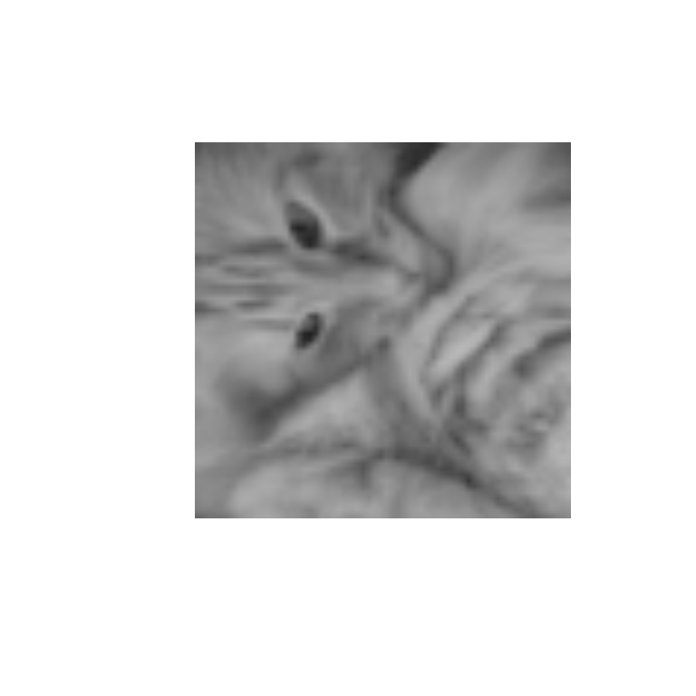

```r
 # Normalize pixel values (0-255 to 0-1) for plotting
first_cat_image_red_channel_normalized <- first_cat_image_red_channel_raw / 255
# For a single channel, higher values will appear brighter.
plot(as.raster(first_cat_image_red_channel_normalized),
     main = "First Image: Red Channel Only (Grayscale)")
```

2. **Flattening the Images**

As we have seen, the image data is multi-dimensional, however, our logistic regression model, which operates on linear combinations of features, expects each image to be represented as a single, flat vector of features.

[figure not shown]

This step transforms each 3D image array into a 1D vector by concatenating all its pixel values. We then stack these individual vectors to form a 2D matrix, where each row corresponds to a single image (sample) and each column represents a specific pixel feature. This conversion makes the data compatible with standard matrix multiplication operations like $Z = XW$, where $X$ is a `(samples x features)` matrix.

```r
# Flattening the images:
# Each image (accessed by the 4th dimension) is converted to a vector.
# 't()' transposes the result to get samples as rows, features (pixels) as columns.
X_train <- t(apply(train_dataset, 4, as.vector))
X_test <- t(apply(test_dataset, 4, as.vector))
dim(X_train)
```

```
[1]   209 12288
```

```r
dim(X_test)
```

```
[1]    50 12288
```

3. **Converting Labels to a Matrix (Column Vector)**

The labels (0 for non-cat, 1 for cat) are initially loaded as simple numerical vectors. For consistency and robustness in matrix operations within our gradient descent functions (e.g., calculating `y_hat - y`), it’s good practice to explicitly convert these label vectors into single-column matrices. This ensures that matrix multiplication and subtraction behave as expected without unexpected R vector recycling rules.

```r
# Converting labels to a matrix (column vector):
# Ensures y_train and y_test are treated as column matrices for consistent
# matrix operations later in the gradient descent.
y_train <- as.matrix(train_labels)
y_test <- as.matrix(test_labels)
dim(y_train)
```

```
[1] 209   1
```

```r
dim(y_test)
```

```
[1] 50  1
```

**4. Normalizing Pixel Values**

Image pixel intensities range from 0 to 255. This step involves dividing all pixel values by 255 (the max value), scaling them down to a standardized range between 0 and 1.

This normalization is critical for several reasons:

- **Numerical Stability:** Machine learning algorithms, especially those that rely on gradient descent, perform much better and converge more reliably when input features are on a similar, small scale. Large input values can lead to extremely large intermediate calculations ($Z$ values) and gradients, potentially causing numerical overflow or instability.
- **Faster Convergence:** Scaling features to a consistent range helps the optimization algorithm find the optimal weights more efficiently. The sigmoid activation function, in particular, has a very flat gradient for very large or very small inputs; normalizing helps keep inputs within the active range of the sigmoid, where gradients are stronger and learning is more effective.

```r
X_train <- X_train/255
X_test <- X_test/255
```

**5. Adding a Bias Term (Intercept)**

Finally, we add an extra column of `1`s to the leftmost side of our feature matrices (`X_train` and `X_test`).

This column represents the **bias term** (or intercept) for our logistic regression model. In the matrix multiplication $Z = XW$, if $X$ includes this column of ones, the first element of the weight vector $W$ will correspond to $\beta_0$ (the intercept). This allows the model to learn a baseline probability (or a baseline activation) even if all other feature values are zero. It effectively shifts the decision boundary, giving the model more flexibility to fit the data.

```r
# Prepends a column of '1's to the feature matrices. This allows the model
# to learn an intercept, which is a baseline prediction independent of features.
X_train <- cbind(1, X_train)
X_test <- cbind(1, X_test)

# --- Display Final Dimensions for Verification ---
# These outputs confirm the shape of your data matrices after preprocessing.
cat("--- Final Data Dimensions (after preprocessing) ---\n")
```

```
--- Final Data Dimensions (after preprocessing) ---
```

```r
cat("Dimensions of X_train (samples x (features + bias)):", dim(X_train), "\n")
```

```
Dimensions of X_train (samples x (features + bias)): 209 12289
```

```r
cat("Dimensions of y_train (samples x 1):", dim(y_train), "\n")
```

```
Dimensions of y_train (samples x 1): 209 1
```

```r
cat("Dimensions of X_test (samples x (features + bias)):", dim(X_test), "\n")
```

```
Dimensions of X_test (samples x (features + bias)): 50 12289
```

```r
cat("Dimensions of y_test (samples x 1):", dim(y_test), "\n")
```

```
Dimensions of y_test (samples x 1): 50 1
```

**Building the parts of our algorithm**

The main steps for building a neural network are:

1. Define the model structure (such as number of input features)
2. Initialize the model’s parameters
3. loop:
   1. Calculate current loss (forward propagation)
   2. Calculate current gradient (Backward propagation)
   3. Update parameters (gradient descent)
4. You often build 1-3 separately and integrate them into one function we call model.

Let’s start:

For one sample image $x_i$ :

$$z_i= w^Tx_i+b$$
the probability of belonging to the cat class will be calculated as:

$$\hat{y_i} = a_i = sigmoid(z_i)$$

where the formula for the *sigmoid* function is:

$$\sigma(Z) = \frac{1}{1 + e^{-Z}}$$

and loss function:
$$L = -\frac{1}{m} \sum_{i=1}^{m} \left[ y_i \log(\hat{y}_i) + (1 - y_i) \log(1 - \hat{y}_i) \right]$$

so for each image $x_i$:

$$L(a_i,y_i) = -y_i \log(a_i)- (1-y_i)log(1-a_i)$$

The cost is then computed by summing over all training examples:

$$J=\frac{1}{m} \sum^m_{i=1} L(a_1,y_i)$$

This will:

- initialize the parameters of the model
- learn the parameters for the model by minimizing the cost
- Use the learned parameters to make predictions (on the test set)
- Analyse the results.

**Create the helper functions**

Implement `sigmoid()` where $z$ is a scalar or array of any size

```r
# Sigmoid function
sigmoid <- function(z) {
  return(1 / (1 + exp(-z)))
}
```

Initialize a initial weight vector with zeros:

```r
initialize_W_with_zeros<- function(dim){
  w = matrix(0,dim,1)
}
```

Initialize bias as 0

```r
bias = 0
```

The activated input will be the *sigmoid* for all the $x_i$ values:

$$A= (a_1,a_2,\cdots,a_m)$$

and $a_1 = sigmoid (W^T x_i + b)$

When we apply the formula above in our code, we do it differently: $XW+b$ The difference between the mathematical notation $(W^T x_i + b)$ and the R code `X %*%W +b` is due to how vector and matrix dimensions are conceptualized and applied in different contexts. Both approaches are mathematically equivalent: In many mathematical texts and derivations, $W$ (the weight vector) is typically represented as a column vector of dimensions (number_of_features X 1). $x_i$ (a single input sample) is also typically represented as a column vector. To compute the doc product for a single sample, you need to multiply a row vector by a column vector, therefore, you just transpose $W$ to get $W^T$ (a $1 \times \text{number_of_features}$ row vector), which can then be multiplied by $x_i$. This results in a $1 \times 1$ scalar value for $z_i$ for that single sample.

In `R` and many other programming languages and machine language libraries, the standard convention for the input matrix $X$ is *Rows represent individual samples* and *Columns represent features.*

```r
# Computes the activated output (predicted probabilities A) given weights W, bias b, and input X.
# Returns: A vector/matrix of activated outputs (probabilities), (samples x 1)

activate <- function(W, b, X){
  Z <- X %*% W + b

  # Apply the sigmoid activation function element-wise to Z
  A <- sigmoid(Z)

  return(A)
}
```

Now we create a function to calculate the *binary cross-entropy loss*:

$$L = -\frac{1}{m} \sum_{i=1}^{m} \left[ y_i \log(\hat{y}_i) + (1 - y_i) \log(1 - \hat{y}_i) \right]$$

```r
# Returns: A single scalar value representing the total cost.
cost_function <- function(W, b, X, Y) {
  # Calculate the number of samples (m) from the dimensions of X
  m <- nrow(X)

  # Calculate the activated output (predicted probabilities A) using the activate function
  A <- activate(W, b, X)

  # Calculate the binary cross-entropy loss
  cost <- - (1/m) * sum(Y * log(A) + (1 - Y) * log(1 - A))

  return(cost)
}
```

Where:

- $w$ is the weights matrix, it will be an array of the same dimensions as features in the flattered dataset ($64 \times 64 \times 3, 1$)
- $b$ is a scalar representing the bias
- $X$ is the data (our flattened array)
- $Y$ is the labels matrix

**Understanding Cost**

In machine learning, a **cost function** is a mathematical measure of how well (or how poorly) a model performs relative to its task. It quantifies the “error” or “discrepancy” between the model’s predicted output and the actual true values (labels) in your training data.

Think of it as a scoring system:

- **Low Cost:** Indicates that your model’s predictions are very close to the actual values.
- **High Cost:** Means your model’s predictions are significantly different from the actual values, indicating poor performance.

The primary goal of training a machine learning model is to **minimize this cost function**. We do this by adjusting the model’s internal parameters (your weights $W$ and bias $b$) during the learning process (*gradient descent*).

**The Binary Cross-Entropy Cost Function in Detail**

In our cat/non-cat example, we’re using a specific type of cost function called **Binary Cross-Entropy (BCE) Loss**, also known as **Log Loss**. This is the standard choice for binary classification problems (where there are only two possible outcomes, like cat/non-cat, 0/1, true/false).

$$L(a_i,y_i) = -y_i \log(a_i)- (1-y_i)log(1-a_i)$$

This single-example loss function behaves differently depending on the true label $y_i$:

1. **When** $y_i=1$ (it’s a cat): The formula simplifies to:

$$L(a_i, 1) = -1 \cdot \log(a_i) - (1 - 1) \cdot \log(1-a_i)$$
$$L(a_i, 1) = -\log(a_i) -0$$

- In this case, the cost is only influenced by $\log(a_i)$.
- If the model predicts a high probability for a cat ($a_i$ close to 1), $\log(a_i)$ will be close to 0 (since $\log(1)=0$), and thus the loss $\log(a_i)$ will be close to 0. This is good!
- If the model incorrectly predicts a low probability for a cat ($a_i$ close to 0), $\log(a_i)$ will be a large negative number (e.g., $\log(0.01)≈−4.6$), and thus the loss $-\log(a_i)$ will be a large positive number (e.g., 4.6). This penalizes the model heavily for being confident but wrong.
2. **When** $y_i=0$ (it’s a non-cat): The formula simplifies to:
   $$L(a_i, 0) = -0 \cdot \log(a_i) - (1 - 0) \cdot \log(1 - a_i)$$
   $$L(a_i, 0) = -\log(1 - a_i)$$
   Here, the cost is only influenced by $\log(1−a_i)$.
- If the model predicts a low probability for a cat ($a_i$) close to 0, meaning $1−a_i$ is close to 1), $\log(1−a_i)$ will be close to 0, and the loss: $-\log(1−a_i)$) will be close to 0.
- If the model incorrectly predicts a high probability for a cat ($a_i$ close to 1, meaning $1−a_i$ is close to 0), $\log(1−a_i)$ will be a large negative number, and the loss $-\log(1−a_i)$) will be a large positive number. Again, this penalizes confident wrong predictions.

**The total Cost(**$J$**)**: The overall cost $J$ for the entire training set is the average of the individual losses over all $m$ training examples:
$$J= \frac{1}{m}\sum_{i=1}^m L(a_1,y_i)$$
Averaging the cost is representative of the model’s performance across the entire dataset, and it makes the cost function less sensitive to the size of the training set.

**Cost vs. Accuracy** It’s important to distinguish between “cost” and “accuracy”:

- Cost (e.g., BCE Loss): This is a continuous value that measures the overall “error” of the model. It’s what the optimization algorithm directly tries to minimize. It’s often not directly interpretable as “percentage correct” but provides a nuanced measure of certainty and error.
- Accuracy: This is a simple metric that measures the proportion of predictions that were exactly correct (e.g., 90% of images classified correctly). It’s easy for humans to understand, but it’s a discrete measure (either right or wrong).

The logical next step in building a logistic regression model with gradient descent is to implement the “backward pass”, which involves calculating the gradients. **These gradients tell us how much each weight (W) and the bias (b) contribute to the total cost, and in which direction they need to be adjusted to minimize that cost.**

We will create a propagate function. It will combine the forward pass (computing A and cost) with the backward pass (computing the gradients dW and db).

To update our weights (W) and bias (b) during gradient descenct, we need to know the derivative of the *cost function* with respect to these parameters. These derivatives are known as gradients

Gradient of the cost with respect to the weights (dW):
$$dw = \frac{1}{m} X^T (A-Y)$$
In `R` this computes to `(1/m) * t(X) %*% (A-Y)`.

For bias (db):
$$db = \frac{1}{m} \sum_{i=1}^m (A_i-Y_i)$$

in `R` this simplifies to `(1/m)* sum(A-Y)`

```r
# Returns: A list containing 'cost', 'dW', and 'db'.
propagate <- function(W, b, X, Y) {
  # Get the number of samples (m)
  m <- nrow(X)

  # --- Forward Propagation ---
  # 1. Calculate activated output (predicted probabilities A)
  A <- activate(W, b, X)

  # 2. Calculate the cost
  cost <- cost_function(W, b, X, Y) # Using the integrated cost_function

  # --- Backward Propagation (Calculate Gradients) ---
  # 1. Calculate gradient for weights (dW)

  dW <- (1/m) * (t(X) %*% (A - Y))

  # 2. Calculate gradient for bias (db)
  # Sums all elements of (A - Y) and averages them.
  db <- (1/m) * sum(A - Y)

  # Store gradients in a list
  gradients <- list(dW = dW, db = db)

  # Return results as a list
  return(list(cost = cost, gradients = gradients))
}
```

**Optimization: Learning with Gradient descent**

Now that we have a function (propagate) that can calculate the cost and the gradients, we need to use those gradients to “learn”. This is done through an optimization algorithm called *Gradient Descent*.

The core idea is simple: we will iteratively adjust our parameters, $W$ and $b$, in the direction that minimally reduces the cost function $J$. The gradients, $dW$ and $db$, tell us the direction of the steepest ascent of the cost function, so to decrease the cost, we move in the opposite direction.

The update rules for the parameters are:
$$W = W- \alpha \cdot dW$$

$$b = b- \alpha \cdot db$$
Alpha is the learning rate, a crucial hyperparameter that controls how large of a step we take during each update. If $\alpha$ is too large, we might overshoot the optimal value. If it is too small, the training process will be very slow. Finding a good learning rate is a key part of training neural networks

Let’s create an `optimize()` function that performs this process for a specified number of iterations

```r
# This function optimizes W and b by running a gradient descent algorithm.
#
# Arguments:
# W              -- weights, a numerical matrix of size (num_features, 1)
# b              -- bias, a scalar
# X              -- data of size (num_samples, num_features)
# Y              -- true "label" vector (e.g., 0 for non-cat, 1 for cat)
# num_iterations -- number of iterations for the optimization loop
# learning_rate  -- learning rate of the gradient descent update rule
# print_cost     -- if TRUE, prints the cost every 100 iterations
#
# Returns:
# A list containing the final learned parameters (W, b) and a record of the costs.

optimize <- function(W, b, X, Y, num_iterations, learning_rate, print_cost = FALSE) {

  costs <- c() # Vector to store the cost at each interval

  for (i in 1:num_iterations) {
    # Calculate cost and gradient for the current parameters (W, b)
    results <- propagate(W, b, X, Y)
    cost <- results$cost
    gradients <- results$gradients
    dW <- gradients$dW
    db <- gradients$db

    # Update rule for W and b
    W <- W - learning_rate * dW
    b <- b - learning_rate * db

    # Record the cost every 100 iterations
    if (i %% 100 == 0) {
      costs <- c(costs, cost)
      if (print_cost) {
        cat("Cost after iteration", i, ":", cost, "\n")
      }
    }
  }

  # Return the learned parameters and tracked information
  return(list(
    W = W,
    b = b,
    costs = costs,
    gradients = list(dW = dW, db = db)
  ))
}
```

**Making predictions** Once the model has been trained and we have our optimized parameters $W$ and $b$, the final step is to make predictions on new data. The prediction process involves two steps:

1. Calculate the predicted probabilities $\hatY = A = \sigma(XW+b)$ for a given dataset $X$.
2. Convert these probabilities into final predictions (0 or 1). A common convention is to classify an image as cat (1) if its corresponding probability in $A$ is greater than 0.5, and as non-cat (0) otherwise.

```r
# Predicts whether the label is 0 or 1 using learned logistic regression parameters (W, b).
#
# Arguments:
# W -- weights, a numerical matrix of size (num_features, 1)
# b -- bias, a scalar
# X -- data of size (num_samples, num_features)
#
# Returns:
# Y_prediction -- a vector of size (num_samples, 1) containing all predictions (0/1) for the examples in X.
predict <- function(W, b, X) {

  m <- nrow(X)
  Y_prediction <- matrix(0, m, 1)

  # Compute the activation (probabilities) for the input data X
  A <- activate(W, b, X)

  # Convert probabilities to actual predictions
  for (i in 1:nrow(A)) {
    if (A[i, 1] > 0.5) {
      Y_prediction[i, 1] <- 1
    } else {
      Y_prediction[i, 1] <- 0
    }
  }

  return(Y_prediction)
}
```

**Integrating everything into a complete model**

We now have all the necessary components. The final step is to assemble them into a single, high level model function. This function will orchestrate the entire workflow: it will initialize the parameters, call the `optimize()` function to train them, and then use the `predict()` function to evaluate the model’s performance on both the training and the test data sets.

```r
# Builds the logistic regression model by calling the functions we've implemented.
#
# Arguments:
# X_train, Y_train -- training set and its labels
# X_test, Y_test   -- test set and its labels
# num_iterations   -- hyperparameter for the number of training iterations
# learning_rate    -- hyperparameter for the optimization step
# print_cost       -- if TRUE, prints the cost during training
#
# Returns:
# A list containing information about the trained model.
model <- function(X_train, Y_train, X_test, Y_test, num_iterations = 2000, learning_rate = 0.5, print_cost = FALSE) {

  # 1. Initialize parameters with zeros
  # The number of features corresponds to the number of columns in X_train
  num_features <- ncol(X_train)
  W <- initialize_W_with_zeros(num_features)
  b <- 0

  # 2. Gradient Descent: Learn parameters by calling optimize()
  optimization_results <- optimize(W, b, X_train, Y_train, num_iterations, learning_rate, print_cost)

  W_final <- optimization_results$W
  b_final <- optimization_results$b
  costs <- optimization_results$costs

  # 3. Predict on the training and test sets
  Y_prediction_test <- predict(W_final, b_final, X_test)
  Y_prediction_train <- predict(W_final, b_final, X_train)

  # 4. Calculate and print accuracies
  train_accuracy <- 100 - mean(abs(Y_prediction_train - Y_train)) * 100
  test_accuracy <- 100 - mean(abs(Y_prediction_test - Y_test)) * 100

  cat("\n-------------------------------------------\n")
  cat("Train Accuracy:", train_accuracy, "%\n")
  cat("Test Accuracy:", test_accuracy, "%\n")
  cat("-------------------------------------------\n")

  # Return a comprehensive list of model results
  return(list(
    costs = costs,
    Y_prediction_test = Y_prediction_test,
    Y_prediction_train = Y_prediction_train,
    W = W_final,
    b = b_final,
    learning_rate = learning_rate,
    num_iterations = num_iterations
  ))
}
```

**Training the model and analyzing the results**

Let’s call our `model()` function with our preprocessed data and see how well it performs. We will set the learning rate to $0.005$ and run for 2000 iterations.

```r
# Set hyperparameters
learning_rate_val <- 0.005
num_iterations_val <- 2000

# Run the model
model_results <- model(X_train, y_train, X_test, y_test,
                       num_iterations = num_iterations_val,
                       learning_rate = learning_rate_val,
                       print_cost = TRUE)
```

```
Cost after iteration 100 : 0.6454642
Cost after iteration 200 : 0.4853574
Cost after iteration 300 : 0.3779958
Cost after iteration 400 : 0.3317399
Cost after iteration 500 : 0.3035048
Cost after iteration 600 : 0.2800795
Cost after iteration 700 : 0.2602181
Cost after iteration 800 : 0.2430976
Cost after iteration 900 : 0.2281456
Cost after iteration 1000 : 0.2149477
Cost after iteration 1100 : 0.2031951
Cost after iteration 1200 : 0.1926513
Cost after iteration 1300 : 0.1831317
Cost after iteration 1400 : 0.1744892
Cost after iteration 1500 : 0.1666051
Cost after iteration 1600 : 0.159382
Cost after iteration 1700 : 0.1527393
Cost after iteration 1800 : 0.1466091
Cost after iteration 1900 : 0.1409344
Cost after iteration 2000 : 0.1356662

-------------------------------------------
Train Accuracy: 99.04306 %
Test Accuracy: 70 %
-------------------------------------------
```

**Analyzing the learning curve**

A great way to check if our gradient descent is working correctly is to plot the cost against the number of iterations. If the model is learning, we should see the cost steadily decrease over time.

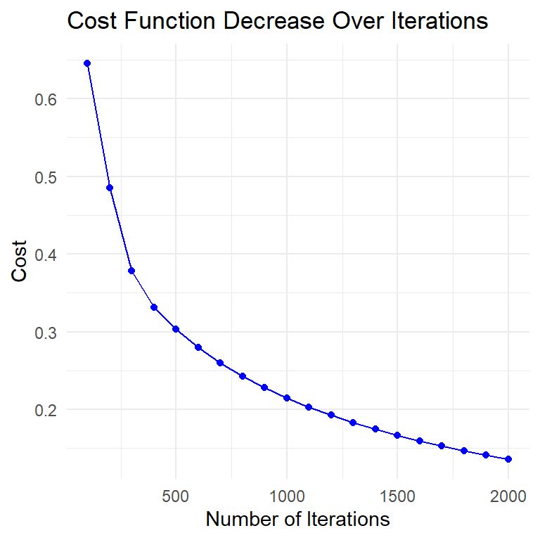

```r
library(ggplot2)

# Create a data frame for plotting
cost_data <- data.frame(
  iterations = seq(100, num_iterations_val, by = 100),
  cost = model_results$costs
)

# Plot the cost
ggplot(cost_data, aes(x = iterations, y = cost)) +
  geom_line(color = "blue") +
  geom_point(color = "blue") +
  labs(
    title = "Cost Function Decrease Over Iterations",
    x = "Number of Iterations",
    y = "Cost"
  ) +
  theme_minimal()
```